# Lab One: Visualization and Data Preprocessing

# Explore Joint Attributes

```python
corrColumnNames = ['flicensed_teach_pct',
 'tchyrs_0thru3_pct',
 'tchyrs_4thru10_pct',
 'tchyrs_11plus_pct',
 'class_teach_num',
 'nbpts_num',
 'advance_dgr_pct',
 'sch_percent_enrolled',
 'lea_percent_enrolled']

dfCorr = dfMergedSet[corrColumnNames].corr('pearson')
```

```
Text(0.5,1,'Scatter Plot Matrix of Teacher Attributes and College Enrollment Percentages')
```

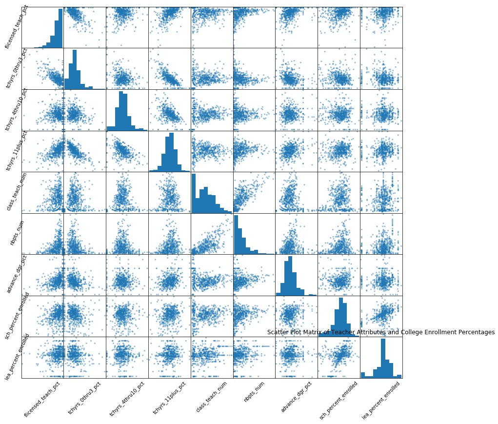

```python
#scatter plot matrix of all attributes
ax = scatter_matrix(dfMergedSet[corrColumnNames], figsize = (14, 14))
#rotate labels
[s.xaxis.label.set_rotation(45) for s in ax.reshape(-1)]
[s.yaxis.label.set_rotation(65) for s in ax.reshape(-1)]
#hide tick marks
[s.set_xticks(()) for s in ax.reshape(-1)]
[s.set_yticks(()) for s in ax.reshape(-1)]
plt.title('Scatter Plot Matrix of Teacher Attributes and College Enrollment Percentages')
```

A key take away from the histograms shown are that the attributes are mostly normally distributed.

Execeptions are of the percentage of teachers who are licensed at a school, which is highly left skewed due to many schools hiring teachers who have their teaching license. Another exception is the percentage of teachers with little experience (0-3 years) per school being right skewed, showing that schools have a majority of staff that exceed this experience threshold. Another right skewed distribution is seen for the number of National Board Certified Staff at the school level (nbpts_num). Since this is not normalized and simply a count per school, this is a major reason why it is right skewed. As seen in the scatter plot, this highly correlates with the average number of classroom teachers at the school level (class_teach_num) because clearly as the average number of teachers at a school increases, the likelihood of the staff count being board certified will increase as well.

Most of the scatterplots show a near random cloud distribution or a normal distribution between two attributes. The most evident of negative correlations are seen in the comparison of the different experience levels. As the percentage of one of the experience levels increase at a school, by default the others must decrease.

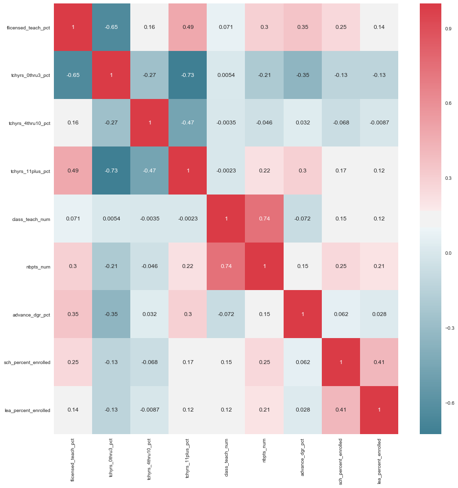

```python
# plot the correlation matrix using seaborn
sns.set(style="darkgrid") # one of the many styles to plot using

f, ax = plt.subplots(figsize=(14, 14))

sns.heatmap(dfMergedSet[corrColumnNames].corr(), cmap=cmap, annot=True)

f.tight_layout()
```

```python
# https://stackoverflow.com/questions/17778394/list-highest-correlation-pairs-from-a-large-correlation-matrix-in-pandas
def get_redundant_pairs(df):
    '''Get diagonal and lower triangular pairs of correlation matrix'''
    pairs_to_drop = set()
    cols = df.columns
    for i in range(0, df.shape[1]):
        for j in range(0, i+1):
            pairs_to_drop.add((cols[i], cols[j]))
    return pairs_to_drop

def get_top_abs_correlations(df, n=5):
    au_corr = df.corr().abs().unstack()
    labels_to_drop = get_redundant_pairs(df)
    au_corr = au_corr.drop(labels=labels_to_drop).sort_values(ascending=False)
    return au_corr[0:n]

print("Top Absolute Correlations")
print(get_top_abs_correlations(dfCorr, 10))
```

```
Top Absolute Correlations
flicensed_teach_pct   tchyrs_0thru3_pct      0.92
class_teach_num       nbpts_num              0.86
tchyrs_0thru3_pct     tchyrs_11plus_pct      0.82
flicensed_teach_pct   tchyrs_11plus_pct      0.77
tchyrs_0thru3_pct     advance_dgr_pct        0.64
flicensed_teach_pct   advance_dgr_pct        0.60
sch_percent_enrolled  lea_percent_enrolled   0.59
tchyrs_11plus_pct     advance_dgr_pct        0.57
tchyrs_4thru10_pct    tchyrs_11plus_pct      0.44
tchyrs_11plus_pct     nbpts_num              0.37
dtype: float64
```

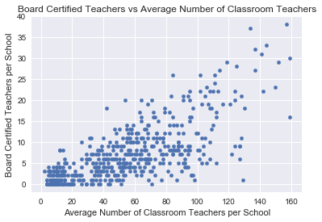

```python
ax = dfMergedSet.plot.scatter(x='class_teach_num', y='nbpts_num') \
 .set(title='Board Certified Teachers vs Average Number of Classroom Teachers',
      xlabel='Average Number of Classroom Teachers per School',
      ylabel='Board Certified Teachers per School')
```

When plotting the average number of classroom teachers at the school level versus the number of National Board Certified Staff at the school level, there is a strong positive correlation. As the average number of classroom teachers at the school level increases, so does the number of National Board Certified Staff. This is likely a clear example of correlation does not mean causation. The more teachers there are at a school, the likelihood of a raw count of National Board Certified Staff will increase.

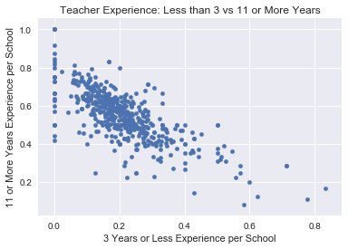

```python
ax = dfMergedSet.plot.scatter(x='tchyrs_0thru3_pct', y='tchyrs_11plus_pct') \
     .set(title='Teacher Experience: Less than 3 vs 11 or More Years',
         xlabel='3 Years or Less Experience per School',
         ylabel='11 or More Years Experience per School')
```

When plotting the percent experience of the teachers at a school there is obviously a negative correlation when you plot two ranges against one another. As the ratio of teachers who have 11+ years at a particular school increases, the rest of the experience ranges (0-3 years in this case) must decrease if the amount of teachers at the school stays constant. The inverse would be true as well.

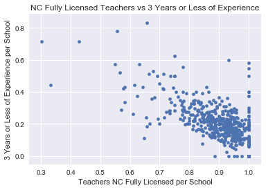

```python
ax = dfMergedSet.plot.scatter(x='flicensed_teach_pct', y='tchyrs_0thru3_pct') \
     .set(title='NC Fully Licensed Teachers vs 3 Years or Less of Experience',
         xlabel='Teachers NC Fully Licensed per School',
         ylabel='3 Years or Less of Experience per School')
```

When plotting the percent of teachers with entry level experience (0-3 years) versus the percent of teachers who are licensed at a school, there is an evident negative linear correlation. As the percent of teachers who are licensed at a school increases, the percent of teachers with entry level experience decreases.

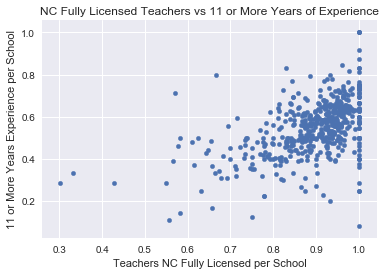

```python
ax = dfMergedSet.plot.scatter(x='flicensed_teach_pct', y='tchyrs_11plus_pct') \
    .set(title='NC Fully Licensed Teachers vs 11 or More Years of Experience',
         xlabel='Teachers NC Fully Licensed per School',
         ylabel='11 or More Years Experience per School')
```

When plotting the percent of teachers with 11+ years of experience versus the percent of teachers who are licensed at a school, there is an evident positive linear correlation. As the percent of teachers who are licensed at a school increases as does the percent of teachers with 11+ years of experience.

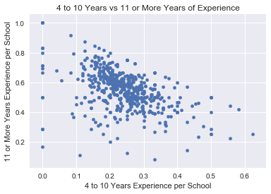

```python
ax = dfMergedSet.plot.scatter(x='tchyrs_4thru10_pct', y='tchyrs_11plus_pct') \
     .set(title='4 to 10 Years vs 11 or More Years of Experience',
         xlabel='4 to 10 Years Experience per School',
         ylabel='11 or More Years Experience per School')
```

When plotting the percent experience of the teachers at a school, there is obviously a negative correlation when you plot two ranges against one another. As the ratio of teachers who have 11+ years at a particular school increases, the rest of the experience ranges (4-10 years in this case) must decrease if the amount of teachers at the school stays constant. The inverse would be true as well.

# Explore Attributes and Class

NEW MATERIAL

```python
dfMergedSet["meet_enrollment_pct"] = dfMergedSet['sch_percent_enrolled'].apply(lambda x: 1 if x > 51 else 0)
```

```
[Text(0,0.5,'Students in % (0-100)'),
 Text(0.5,0,'Teachers in % (0.0 to 1)'),
 Text(0.5,1,'Percentage of Teachers with Advanced Degrees vs. % of students enrolled post high school')]
```

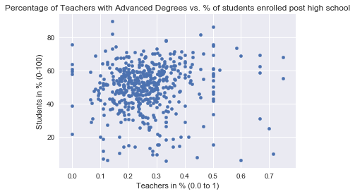

```python
### CREATE NEW SCATTER PLOTS PLOTTING % ENROLLED IN POST-SECONDARY AND EACH FEATURE LISTED ABOVE
### % STUDENTS IN POST-SECONDARY VS ADVANCED DEGREES
(dfMergedSet
 .plot
 .scatter(x='advance_dgr_pct', y='sch_percent_enrolled')
 .set(title='Percentage of Teachers with Advanced Degrees vs. % of students enrolled post high school',
      xlabel='Teachers in % (0.0 to 1)',
      ylabel='Students in % (0-100)'))
```

There appears to be no correlation between teachers with advanced degrees and the percentage of students enrolled in a post-secondary institution since the scatter plot resembles a random cloud.

```
[Text(0,0.5,'Students in % (0-100)'),
 Text(0.5,0,'Teachers in % (0.0 to 1)'),
 Text(0.5,1,'Percentage of Licensed Teachers vs. % of students enrolled post high school')]
```

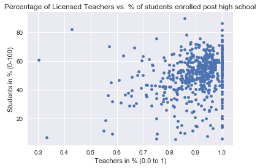

```python
### % STUDENTS IN POST-SECONDARY VS Flicensed_teach_pct
(dfMergedSet
 .plot
 .scatter(x='flicensed_teach_pct', y='sch_percent_enrolled')
 .set(title='Percentage of Licensed Teachers vs. % of students enrolled post high school',
      xlabel='Teachers in % (0.0 to 1)',
      ylabel='Students in % (0-100)'))
```

The majority of schools have over 50% of licensed teachers. There appears to be a weak positive correlation between the percentage of licensed teachers and the percentage of students enrolled in a post-secondary institution after graduating high school.

```
[Text(0,0.5,'Students in % (0-100)'),
 Text(0.5,0,'Number of Teachers'),
 Text(0.5,1,'Average number of teachers per school vs. % of students enrolled post high school')]
```

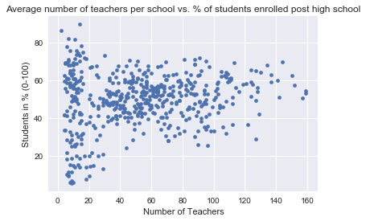

```python
### % Students enrolled in post-secondary VS Class_teach_num
(dfMergedSet
 .plot
 .scatter(x='class_teach_num', y='sch_percent_enrolled')
 .set(title='Average number of teachers per school vs. % of students enrolled post high school',
      xlabel='Number of Teachers',
      ylabel='Students in % (0-100)'))
```

When plotting average number of teachers per year versus the percent of students who enroll in college at those schools you see a very weak linear correlation. However when percent students enrolled is plotted as the x, the average number of teachers per school looks similar to a normal distribution.

```
[Text(0,0.5,'Students in % (0-100)'),
 Text(0.5,0,'Number of NBCS at School'),
 Text(0.5,1,'Number of National Board Certified Staff at school level vs. % of students enrolled post high school')]
```

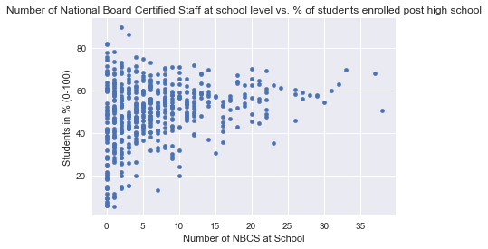

```python
(dfMergedSet
 .plot
 .scatter(x='nbpts_num', y='sch_percent_enrolled')
 .set(title='Number of National Board Certified Staff at school level vs. % of students enrolled post high school',
      xlabel='Number of NBCS at School',
      ylabel='Students in % (0-100)'))
```

```
[Text(0,0.5,'Students in % (0-100)'),
 Text(0.5,0,'% One year teacher turnover'),
 Text(0.5,1,'One year teacher turnover percentage at school level vs. % of students enrolled post high school')]
```

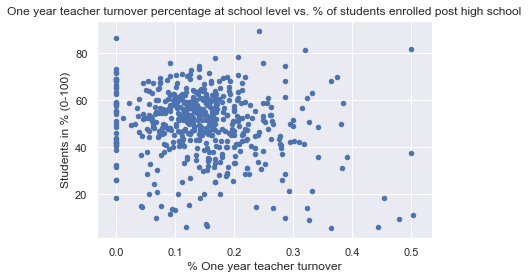

```python
(dfMergedSet
 .plot
 .scatter(x='_1yr_tchr_trnovr_pct', y='sch_percent_enrolled')
 .set(title='One year teacher turnover percentage at school level vs. % of students enrolled post high school',
      xlabel='% One year teacher turnover',
      ylabel='Students in % (0-100)'))
```

To look to see if at a school level if the increase in the percent of teacher turnover per year would effect the percent college enrollment of the students we plotted the two against each other. There looks to be no correlation between the two due to the random distribution. However, when narrowing the scope of instances where the percent teacher turnover in that year was over 40%, 4 out of 6 instances the percent student college enrollment was below 20%. This is more than two standard deviations away from the mean and median college enrollment percentage.

```
[Text(0,0.5,'Students in % (0-100)'),
 Text(0.5,0,'% Teachers w/11+ years experience'),
 Text(0.5,1,'% Teachers with 11+ years experience vs. % of students enrolled post high school')]
```

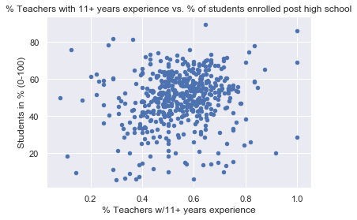

```python
(dfMergedSet
 .plot
 .scatter(x='tchyrs_11plus_pct', y='sch_percent_enrolled')
 .set(title='% Teachers with 11+ years experience vs. % of students enrolled post high school',
      xlabel='% Teachers w/11+ years experience',
      ylabel='Students in % (0-100)'))
```

It is very evident that there is no correlation between the percentage of students who enrolled in college and the percentage of teachers with 11+ years experience at the school.

```
[Text(0,0.5,'Students in % (0-100)'),
 Text(0.5,0,'% Teachers w/0-3 years experience'),
 Text(0.5,1,'% Teachers with 0-3 years experience vs. % of students enrolled post high school')]
```

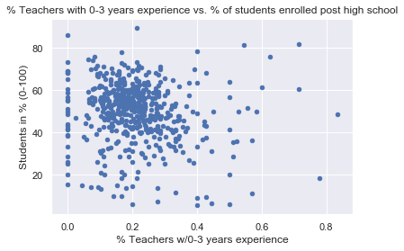

```python
(dfMergedSet
 .plot
 .scatter(x='tchyrs_0thru3_pct', y='sch_percent_enrolled')
 .set(title='% Teachers with 0-3 years experience vs. % of students enrolled post high school',
      xlabel='% Teachers w/0-3 years experience',
      ylabel='Students in % (0-100)'))
```

It is very evident that there is no correlation between the percentage of students who enrolled in college and the percentage of teachers with 0-3 years experience at the school. It looks nearly identical to the plot above with 11+ years of experience for the teachers except for its shift to the left due to their being a smaller percentage of teachers with 0-3 years of experience.

```
Text(0.5,1,'')
```

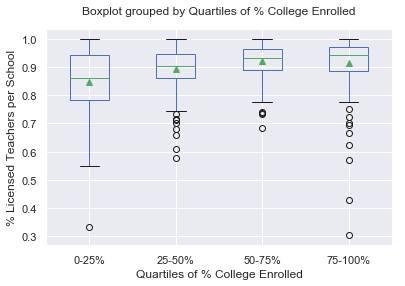

```python
########################################################################################################
############################### NEW PLOT ###############################################################
########################################################################################################

# Code adapted from https://stackoverflow.com/questions/23232989/boxplot-stratified-by-column-in-python-pandas
breaks = np.asarray(np.percentile(dfMergedSet['sch_percent_enrolled'], [25,50,75,100]))
dfMergedSet['Quartiles of % College Enrolled'] = (dfMergedSet['sch_percent_enrolled'].values > breaks[..., np.newaxis]).sum(0)
ax = dfMergedSet.boxplot(column='flicensed_teach_pct', by='Quartiles of % College Enrolled', showmeans=True)
ax.xaxis.set_ticklabels(['0-25%', '25-50%', '50-75%', '75-100%'])
ax.set_xlabel('Quartiles of % College Enrolled')
ax.set_ylabel('% Licensed Teachers per School')
ax.set_title('')
```

To look for differences in distributions of teacher attributes on the percentage of students who enrolled in college we broke this metric into quartiles. There is a clear trend in increasing median percentage of licensed teachers as the quartiles of the percent of students at those schools enrolled in college after graduation. The difference between the lowest and highest quartile is about an eight percent increase in teachers who were licensed. Interestingly, the variability decreases for the quartiles as they increase except for the highest quartile which has more variability than the second quartile even though its median is still higher.

```
Text(0.5,1,'')
```

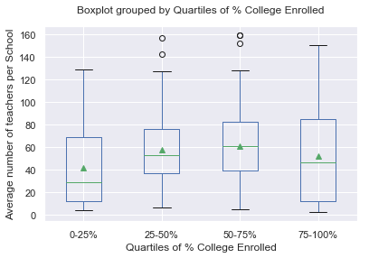

```python
########################################################################################################
############################### NEW PLOT ###############################################################
########################################################################################################

ax = dfMergedSet.boxplot(column='class_teach_num', by='Quartiles of % College Enrolled', showmeans=True)
ax.xaxis.set_ticklabels(['0-25%', '25-50%', '50-75%', '75-100%'])
ax.set_xlabel('Quartiles of % College Enrolled')
ax.set_ylabel('Average number of teachers per School')
ax.set_title('')
```

To look for differences in distributions of teacher attributes on the percentage of students who enrolled in college we broke this metric into quartiles. As the quartiles incrase for the percentage of students who enrolled in college the mean and median of the average number of teachers increased up until the 75-100% quartile. A hypothesis to this trend might be because the upper 75-100% quartile has smaller school sizes thus lowering the average number of teachers needed to teach the student body. This cannot be confirmed though as we do not have the class body size for the schools.

```
Text(0.5,1,'')
```

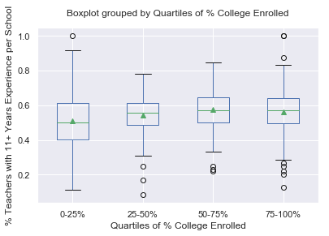

```python
########################################################################################################
############################### NEW PLOT ###############################################################
########################################################################################################

ax = dfMergedSet.boxplot(column='tchyrs_11plus_pct', by='Quartiles of % College Enrolled', showmeans=True)
ax.xaxis.set_ticklabels(['0-25%', '25-50%', '50-75%', '75-100%'])
ax.set_xlabel('Quartiles of % College Enrolled')
ax.set_ylabel('% Teachers with 11+ Years Experience per School')
ax.set_title('')
```

To look for differences in distributions of teacher attributes on the percentage of students who enrolled in college we broke this metric into quartiles. While the median percentage of teachers who have 11+ years of experience increases from the lower quartile (0-25%) of schools who have the lowest percent of students who enroll in college, the median stays very constant in the other three quartiles. A similar trend is apparent for a decrease in variance after the lower quartile but says relatively constant for the other three quartiles.

```
Text(0.5,1,'')
```

[figure not shown]

```python
########################################################################################################
############################### NEW PLOT ###############################################################
########################################################################################################

ax = dfMergedSet.boxplot(column='tchyrs_0thru3_pct', by='Quartiles of % College Enrolled', showmeans=True)
ax.xaxis.set_ticklabels(['0-25%', '25-50%', '50-75%', '75-100%'])
ax.set_xlabel('Quartiles of % College Enrolled')
ax.set_ylabel('% Teachers with 0-3 Years Experience per School')
ax.set_title('')
```

To look for differences in distributions of teacher attributes on the percentage of students who enrolled in college we broke this metric into quartiles. Although there is a decrease in the median % of teachers with 0-3 experience as the quartiles increase for the % of students who enrolled in college per school, it is very small. Of note though is the decreaseing variance as the quartiles increase. This shows that the median school will have a consistent amount of newer teachers to the profession (0-3 years experience) no matter the quartile of percent students who enrolled in college, once it increases beyond that median it is more likely that school will have a lower percent of students who enroll in college.

```
Text(0.5,1,'')
```

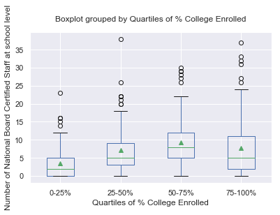

```python
########################################################################################################
############################### NEW PLOT ###############################################################
########################################################################################################

ax = dfMergedSet.boxplot(column='nbpts_num', by='Quartiles of % College Enrolled', showmeans=True)
ax.xaxis.set_ticklabels(['0-25%', '25-50%', '50-75%', '75-100%'])
ax.set_xlabel('Quartiles of % College Enrolled')
ax.set_ylabel('Number of National Board Certified Staff at school level')
ax.set_title('')
```

To look for differences in distributions of teacher attributes on the percentage of students who enrolled in college we broke this metric into quartiles. Since these are raw counts and not normalized the data can be easily misinterpretted due to a school just being very large relative to another. So while their raw count of National Board Certified Staff might be larger than a smaller school their percentage of staff that is certified might be lower. This would effect its relationship with the percent of college enrolled students. With that being said you can see a clear trend that as the quartiles of percent college enrolled students increase, as does the number of certified staff at that school. Interestlingly though the 75-100% quartile does not follow this trend and has a median and average comparable to the 25-50% quartile. Also the variablility of the number of certified staff increases at an approximately linear rate as the quartile of percent college enrolled students increases.

```
Text(0.5,1,'')
```

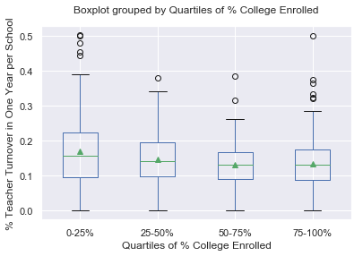

```python
########################################################################################################
############################### NEW PLOT ###############################################################
########################################################################################################

ax = dfMergedSet.boxplot(column='_1yr_tchr_trnovr_pct', by='Quartiles of % College Enrolled', showmeans=True)
ax.xaxis.set_ticklabels(['0-25%', '25-50%', '50-75%', '75-100%'])
ax.set_xlabel('Quartiles of % College Enrolled')
ax.set_ylabel('% Teacher Turnover in One Year per School')
ax.set_title('')
```

To look for differences in distributions of teacher attributes on the percentage of students who enrolled in college we broke this metric into quartiles. Although small, the median and mean percent teacher turnover in one year decreases as the quartiles of percent college enrolled increases. The same trend holds true for the variance as well with a slight exception for the 75-100% quartile's variance having more outliers and variance than the 50-75% quartile.

All of these quartile plots of the percentage of students who enrolled in college exhibit behaviour one might expect from the attribute but at a small level. This might be because while each individual attribute is not all that important, the cumulative effect of them at a school is.

END NEW MATERIAL

# New Features

NEW MATERIAL

After further inspection of the attributes that we have available through the college enrollment and personnel datasets, there don't appear to be any clear indicators of why a school performs better than others. In order to get a more holistic point of view we will need to include all the data provided and found in the ML dataset. This includes student test scores in multiple areas, personnel performance, and more granular information on demographics within the school. By not limiting ourselves to the datasets we originally selected and accounting for any highly correlated attributes, we can allow the machine learning algorithms to have a much broader and richer set of attributes to feed into the model that should allow for better classification results.  
In addition, we could include the national statistics for postsecondary enrollment from https://nces.ed.gov/programs/coe/indicator_cpa.asp. While this information may not help us build a better model, it does allow for the comparison of statistics across the US. It is possible that in some areas, possibly demographics, we can use the aggregated data to adjust the values we use for any missing information and could improve our results.

END NEW MATERIAL

# Exceptional Work

Our team initially started out exploring another data set from Kaggle – Data Science for Social Good: Kiva Crowdfunding. The Kaggle competition asked participants to build localized models to estimate poverty levels where Kiva is providing microloans. After initial exploratory analysis, we found that the data set was not robust enough to support building models due to a lack of clear response variables. Thus, we decided to change to the North Carolina Educational Attainment data. Much of work this week was focused on understanding and connecting the College Enrollment and Personnel data sets. We have additional work to do on the analysis of the resulting joint data.